# business_forecasting_assignment05

Adwait Kalsekar

2023-10-27

# Dataset Information

The dataset chosen for this assignment consists of the House Price Index for the State of New Jersey over the last 50 years calculated quarterly.

Looking at the time series data it can also be inferred that there has been a visible trend in the growth of HPI over the last 50 years. The HPI has increased exponentially since the year 1975 to the year 2023.

Looking at the time series data, certain forecasting models applied have predicted similar future data points that account for the existing trend and seasonality.

## Loading the Dataset and Converting to Time Series

```r
# Loading Libraries
library(fpp)
library(fpp2)
library(TTR)

# Reading Data from CSV File
df = read.csv("NJ_HPI.csv")
str(df)
```

```
## 'data.frame':    194 obs. of  2 variables:
##  $ DATE  : chr  "1975-01-01" "1975-04-01" "1975-07-01" "1975-10-01" ...
##  $ HPI.NJ: num  64.3 59.3 60.1 62.8 62.8 ...
```

```r
# Converting DATE column to R Date Type
df$DATE <- as.Date(df$DATE)
str(df)
```

```
## 'data.frame':    194 obs. of  2 variables:
##  $ DATE  : Date, format: "1975-01-01" "1975-04-01" ...
##  $ HPI.NJ: num  64.3 59.3 60.1 62.8 62.8 ...
```

```r
df
```

```
##           DATE HPI.NJ
## 1   1975-01-01  64.32
## 2   1975-04-01  59.29
## 3   1975-07-01  60.10
## 4   1975-10-01  62.81
## 5   1976-01-01  62.79
## 6   1976-04-01  63.85
## 7   1976-07-01  65.88
## 8   1976-10-01  62.21
## 9   1977-01-01  65.12
## 10  1977-04-01  65.35
## 11  1977-07-01  67.42
## 12  1977-10-01  69.48
## 13  1978-01-01  71.16
## 14  1978-04-01  73.21
```

[output cut: 180 more lines]

```r
# Converting to Time Series data
df_ts = ts(df$HPI.NJ, start=c(1975, 1), end=c(2023, 2), frequency=4)
df_ts
```

```
##        Qtr1   Qtr2   Qtr3   Qtr4
## 1975  64.32  59.29  60.10  62.81
## 1976  62.79  63.85  65.88  62.21
## 1977  65.12  65.35  67.42  69.48
## 1978  71.16  73.21  76.36  79.63
## 1979  85.07  87.02  91.60  94.18
## 1980 100.00 101.55 100.79 103.72
## 1981 104.26 105.86 107.56 105.86
## 1982 105.37 108.91 109.14 109.62
## 1983 110.11 113.74 117.62 120.82
## 1984 123.83 130.15 134.91 138.18
## 1985 142.17 148.46 154.96 161.87
## 1986 167.97 178.06 189.18 199.06
## 1987 210.10 221.27 229.93 235.24
## 1988 240.37 246.40 247.15 246.30
```

[output cut: 35 more lines]

```r
# Attributes and Structure
attributes(df_ts)
```

```
## $tsp
## [1] 1975.00 2023.25    4.00
##
## $class
## [1] "ts"
```

```r
str(df_ts)
```

```
##  Time-Series [1:194] from 1975 to 2023: 64.3 59.3 60.1 62.8 62.8 ...
```

## Plotting and Observing the Time Series

```r
summary(df_ts)
```

```
##    Min. 1st Qu.  Median    Mean 3rd Qu.    Max.
##   59.29  212.89  260.84  330.19  486.63  783.94
```

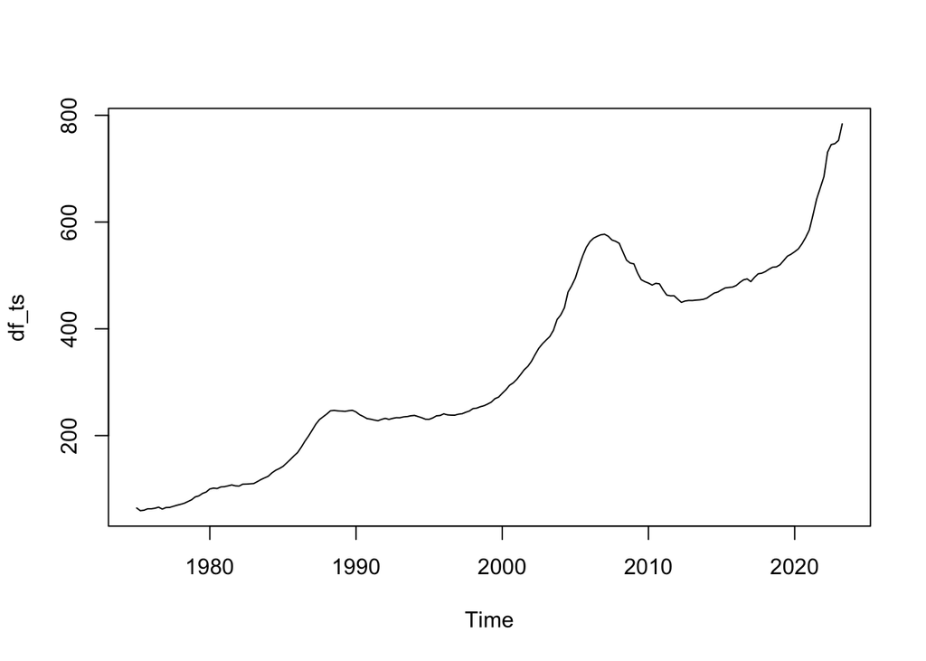

```r
plot(df_ts)
```

# Decomposition

## Seasonal Decomposition of Time Series by Loess (STL) Decomposition

```r
# STL Decomposition
df_ts_stl <- stl(df_ts,s.window ="periodic")
attributes(df_ts_stl)
```

```
## $names
## [1] "time.series" "weights"     "call"        "win"         "deg"
## [6] "jump"        "inner"       "outer"
##
## $class
## [1] "stl"
```

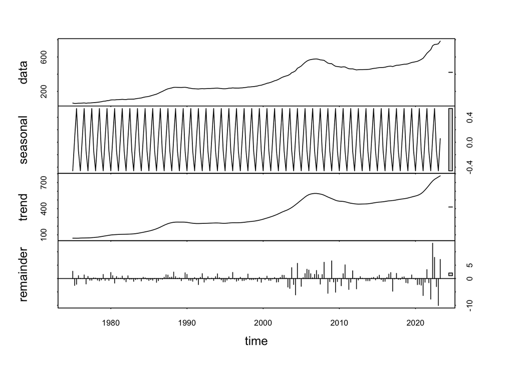

```r
plot(df_ts_stl)
```

## Plotting Trend and Seasonal Components

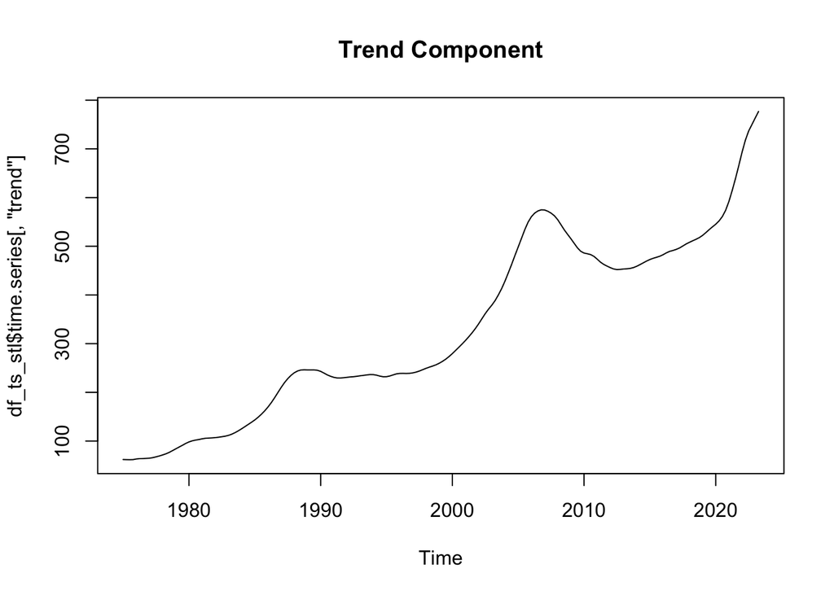

```r
plot(df_ts_stl$time.series[, "trend"], main="Trend Component")
```

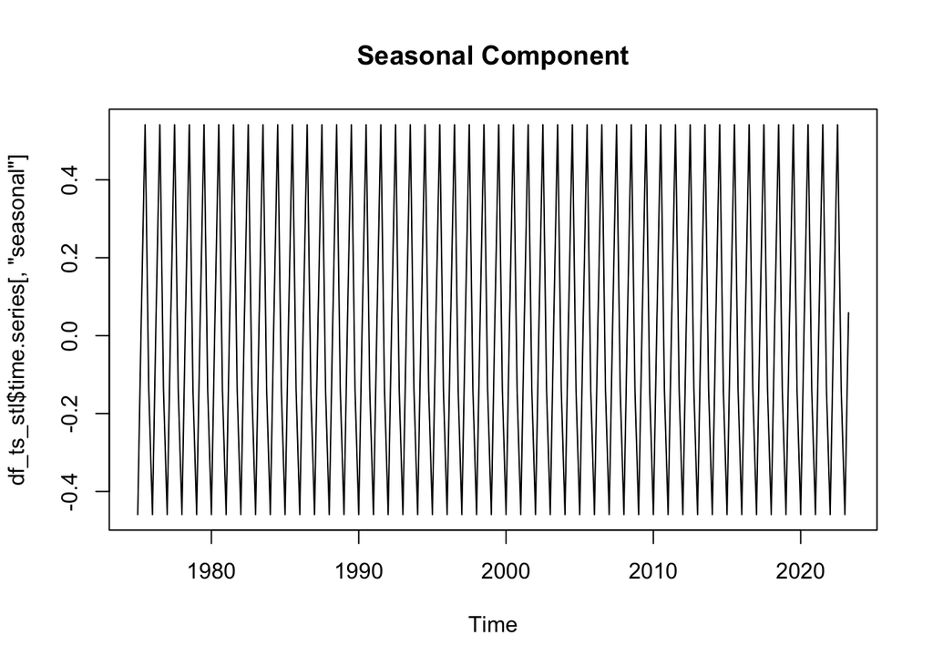

```r
plot(df_ts_stl$time.series[, "seasonal"], main="Seasonal Component")
```

## Seasonally Adjusting Time Series

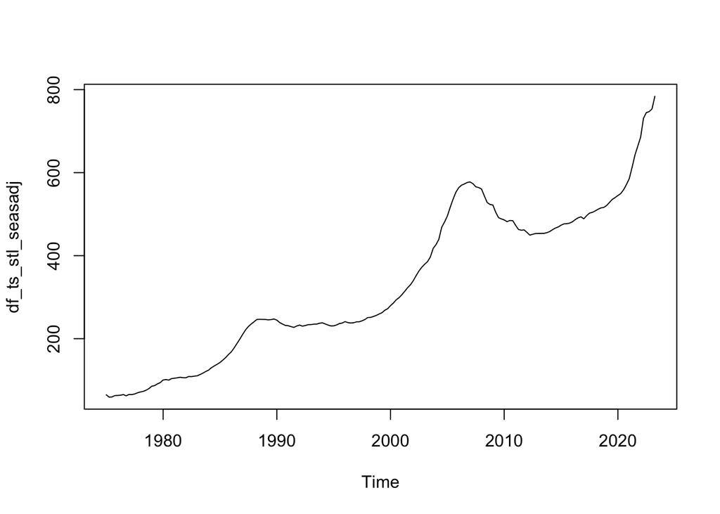

```r
# Seasonal Adjustment
df_ts_stl_seasadj = seasadj(df_ts_stl)
plot(df_ts_stl_seasadj)
```

## Plotting Line for Seasonally Adjusted STL with the original Time Series

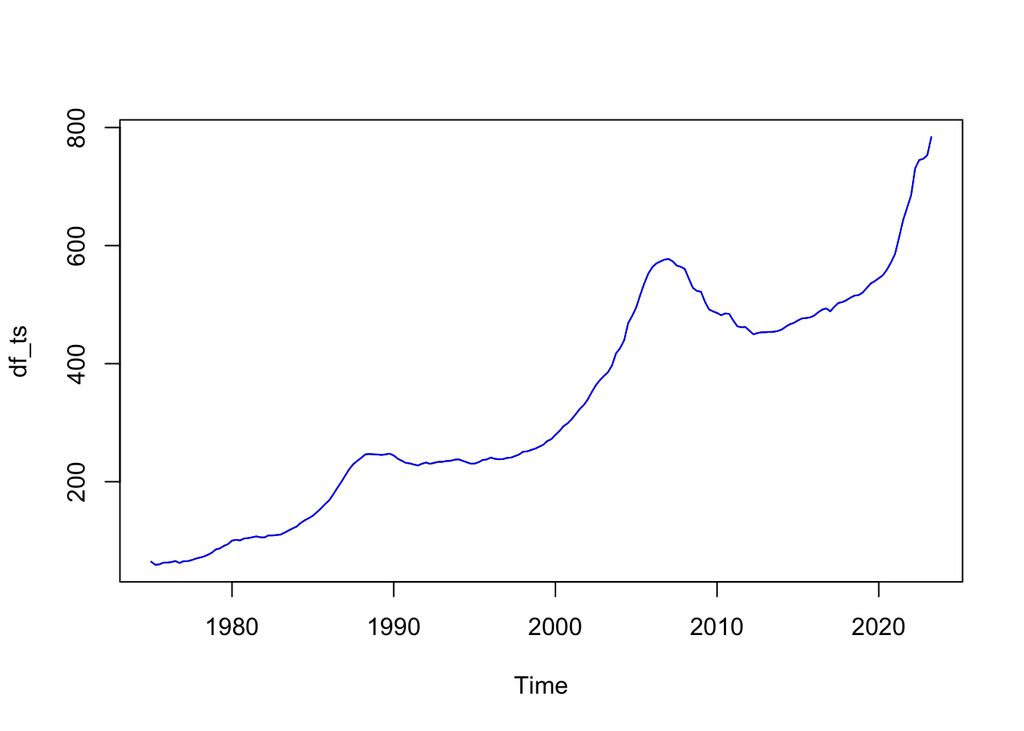

```r
plot(df_ts)
lines(df_ts_stl_seasadj, col="blue")
```

### As the data is not seasonal, there is no difference between seasonally adjusted time series and original time series and the two lines overlap

## Forecasting the Decomposed Time Series

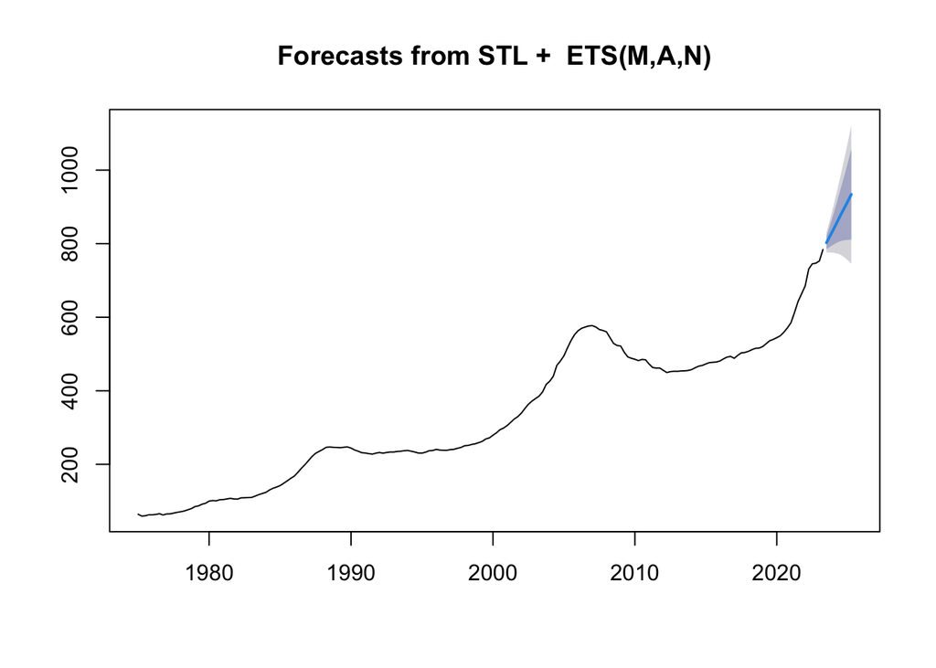

```r
# Default period forecast
df_ts_stl_forecast <- forecast(df_ts_stl)
plot(df_ts_stl_forecast)
```

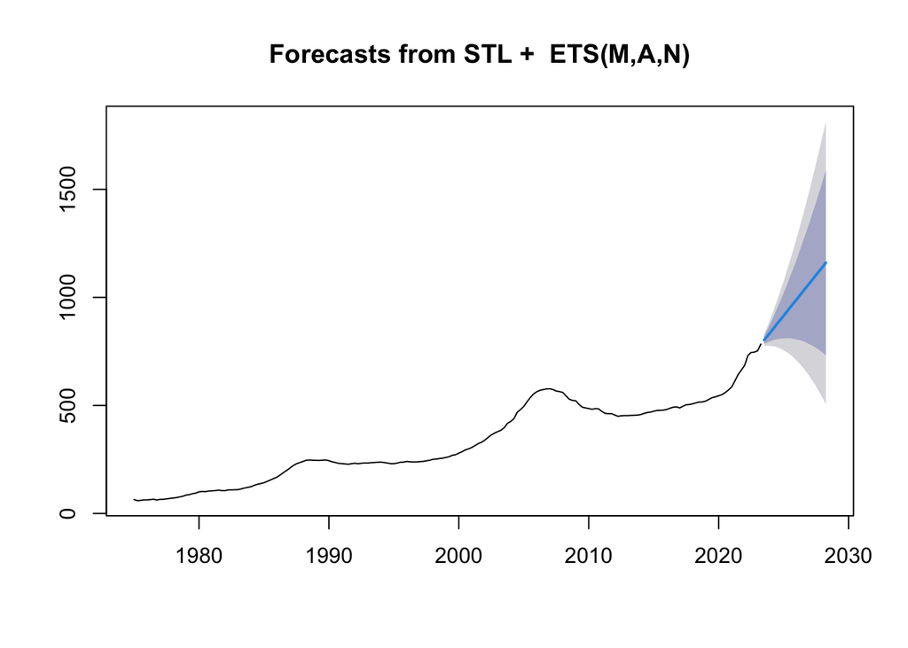

```r
# Passing number of periods
df_ts_stl_forecast_20 <- forecast(df_ts_stl, h=20)
plot(df_ts_stl_forecast_20)
```

## Forecasting the Seasonally Adjusted Decomposed Time Series

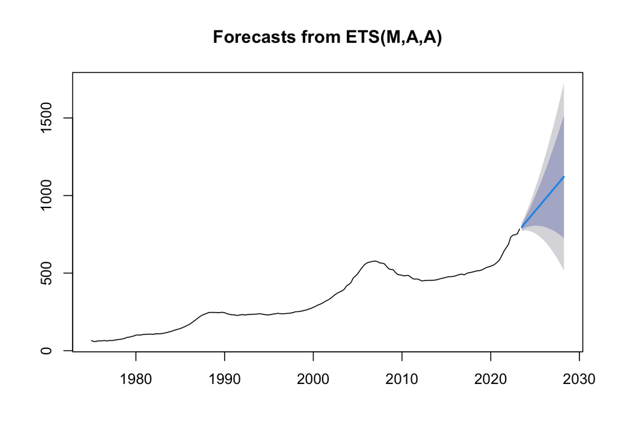

```r
df_ts_stl_seasadj_forecast <- forecast(df_ts_stl_seasadj, h=20)
plot(df_ts_stl_seasadj_forecast)
```

## Using Decompose Function

```r
df_ts_decompose <- decompose(df_ts)
attributes(df_ts_decompose)
```

```
## $names
## [1] "x"        "seasonal" "trend"    "random"   "figure"   "type"
##
## $class
## [1] "decomposed.ts"
```

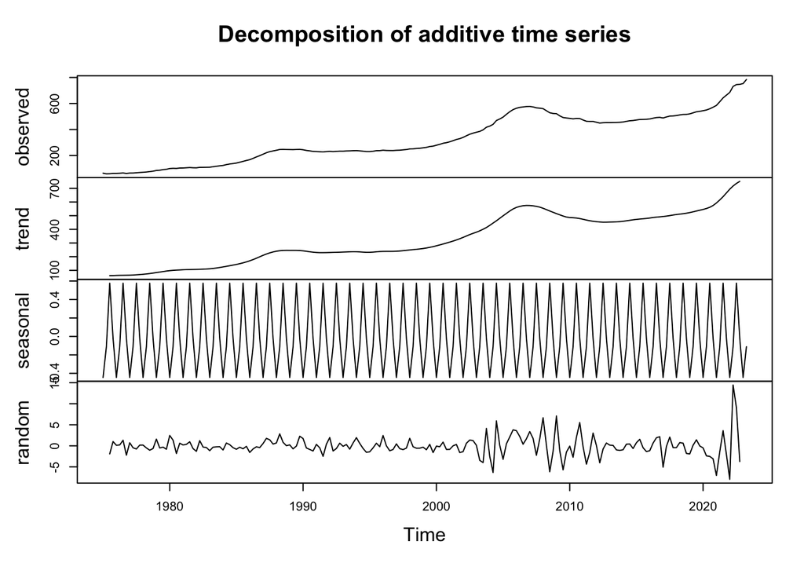

```r
plot(df_ts_decompose)
```

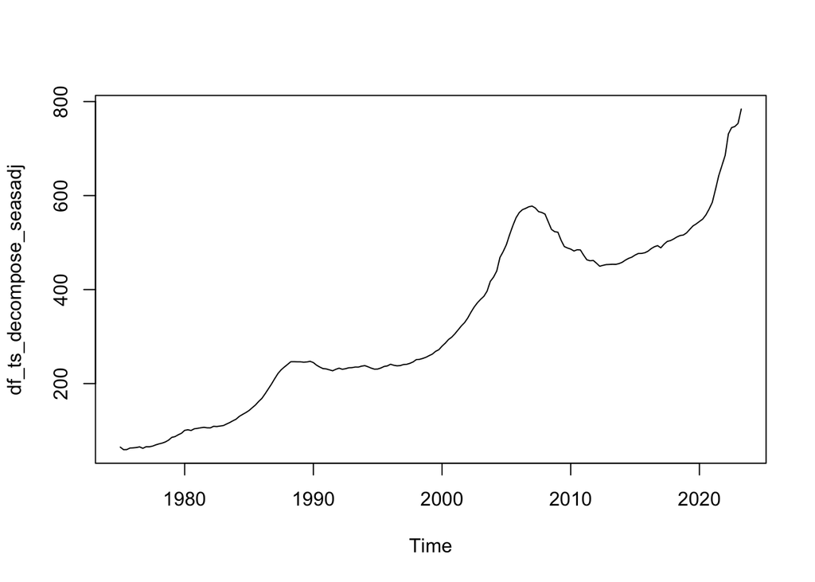

```r
# Seasonal Adjustment
df_ts_decompose_seasadj = seasadj(df_ts_decompose)
plot(df_ts_decompose_seasadj)
```

## Plotting Line Seasonally Adjusted Decomposed TS with the original Time Series

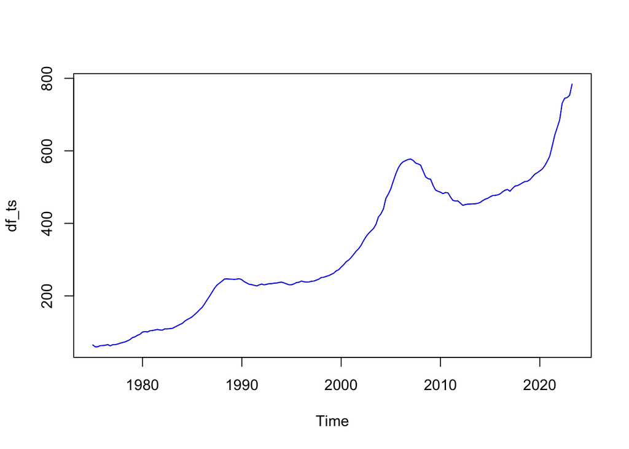

```r
plot(df_ts)
lines(df_ts_decompose_seasadj, col="blue")
```

## Forecasting the Seasonally Adjusted Decomposed Time Series

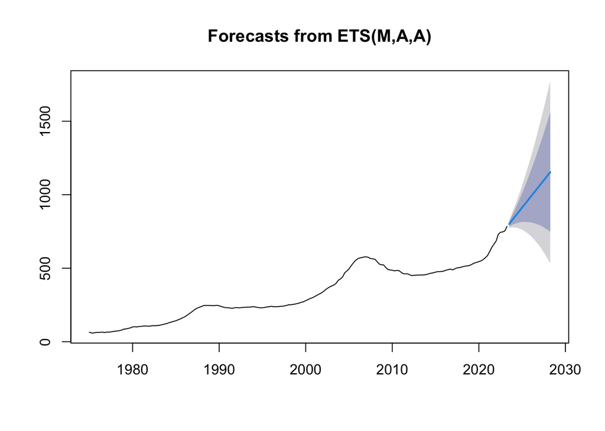

```r
df_ts_decompose_seasadj_forecast <- forecast(df_ts_decompose_seasadj, h=20)
plot(df_ts_decompose_seasadj_forecast)
```